# Most harmful natural events across the United States

Stepan Kuzmin

Feb 14, 2016

## 1. Synopsis

Storms and other severe weather events can cause both public health and economic problems for communities and municipalities. Many severe events can result in fatalities, injuries, and property damage, and preventing such outcomes to the extent possible is a key concern.

This report provides the result of exploring the [NOAA Storm Database](https://www.ncdc.noaa.gov/stormevents/) and answers to following questions:

1. Across the United States, which types of events are most harmful with respect to population health?
2. Across the United States, which types of events have the greatest economic consequences?

## 2. Getting the data

```r
download.file("https://d396qusza40orc.cloudfront.net/repdata%2Fdata%2FStormData.csv.bz2", "StormData.csv.bz2")
data <- read.csv("StormData.csv.bz2", na.strings = c("NA"))
```

```r
colnames(data)
```

```
##  [1] "STATE__"    "BGN_DATE"   "BGN_TIME"   "TIME_ZONE"  "COUNTY"
##  [6] "COUNTYNAME" "STATE"      "EVTYPE"     "BGN_RANGE"  "BGN_AZI"
## [11] "BGN_LOCATI" "END_DATE"   "END_TIME"   "COUNTY_END" "COUNTYENDN"
## [16] "END_RANGE"  "END_AZI"    "END_LOCATI" "LENGTH"     "WIDTH"
## [21] "F"          "MAG"        "FATALITIES" "INJURIES"   "PROPDMG"
## [26] "PROPDMGEXP" "CROPDMG"    "CROPDMGEXP" "WFO"        "STATEOFFIC"
## [31] "ZONENAMES"  "LATITUDE"   "LONGITUDE"  "LATITUDE_E" "LONGITUDE_"
## [36] "REMARKS"    "REFNUM"
```

```r
dim(data)
```

```
## [1] 902297     37
```

## 3. Data processing

```r
library(dplyr)
library(ggplot2)
```

Calculate numbers of fatalities and injuries grouped by natural event types

```r
fatalities_and_injuries_by_type <- data %>%
                                   group_by(EVTYPE) %>%
                                   summarise_each(funs(sum), FATALITIES, INJURIES) %>%
                                   arrange(desc(FATALITIES), desc(INJURIES))
```

Define `calculateDamage` transformation function. This function calculates damage, passed in the first argument, applying exponent, passed as the second argument.

Exponents is equivalent to

- `K`, `k` is kilo
- `M`, `m` is millions
- `B`, `b` is billions

```r
calculateDamage <- function(dmg, exp) {
  switch(as.character(exp),
         "K" = dmg * 1e+03,
         "k" = dmg * 1e+03,
         "M" = dmg * 1e+06,
         "m" = dmg * 1e+06,
         "B" = dmg * 1e+09,
         "b" = dmg * 1e+09,
         dmg
  )
}
```

Calculate property damage and core amount of damage for property by natural event types using previously defined transformation function

```r
propdmg_and_cropdmg_by_type <- data %>%
                               rowwise() %>%
                               mutate(
                                 PROPDMG = calculateDamage(PROPDMG, PROPDMGEXP),
                                 CROPDMG = calculateDamage(CROPDMG, CROPDMGEXP)) %>%
                               ungroup %>%
                               group_by(EVTYPE) %>%
                               summarise_each(funs(sum), PROPDMG, CROPDMG) %>%
                               arrange(desc(PROPDMG), desc(CROPDMG))
```

## 4. Results

### 4.1 Most harmful types of events with respect to population health

```r
most_harmful_to_people = head(fatalities_and_injuries_by_type, 10)
most_harmful_to_people
```

```
## Source: local data frame [10 x 3]
##
##            EVTYPE FATALITIES INJURIES
##            (fctr)      (dbl)    (dbl)
## 1         TORNADO       5633    91346
## 2  EXCESSIVE HEAT       1903     6525
## 3     FLASH FLOOD        978     1777
## 4            HEAT        937     2100
## 5       LIGHTNING        816     5230
## 6       TSTM WIND        504     6957
## 7           FLOOD        470     6789
## 8     RIP CURRENT        368      232
## 9       HIGH WIND        248     1137
## 10      AVALANCHE        224      170
```

Below are the charts showing the results

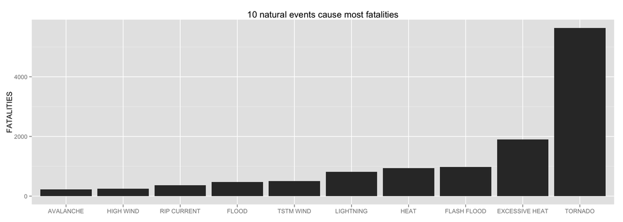

```r
ggplot(most_harmful_to_people, aes(x = reorder(EVTYPE, FATALITIES), y = FATALITIES)) +
  geom_bar(stat = "identity") +
  ggtitle("10 natural events cause most fatalities") +
  ylab("FATALITIES") +
  theme(axis.title.x = element_blank())
```

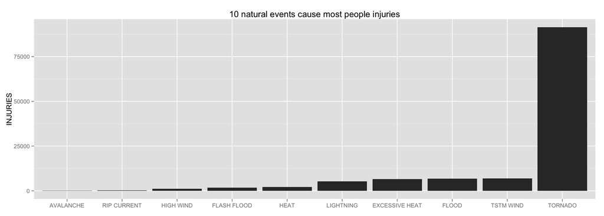

```r
ggplot(most_harmful_to_people) + aes(x = reorder(EVTYPE, INJURIES), y = INJURIES) +
  geom_bar(stat = "identity") +
  ggtitle("10 natural events cause most people injuries") +
  ylab("INJURIES") +
  theme(axis.title.x = element_blank())
```

### 4.2 Most harmful types of events with respect to economic consequences

```r
most_harmful_to_economic = head(propdmg_and_cropdmg_by_type, 10)
most_harmful_to_economic
```

```
## Source: local data frame [10 x 3]
##
##               EVTYPE      PROPDMG    CROPDMG
##               (fctr)        (dbl)      (dbl)
## 1              FLOOD 144657709807 5661968450
## 2  HURRICANE/TYPHOON  69305840000 2607872800
## 3            TORNADO  56937160779  414953270
## 4        STORM SURGE  43323536000       5000
## 5        FLASH FLOOD  16140812067 1421317100
## 6               HAIL  15732267048 3025954473
## 7          HURRICANE  11868319010 2741910000
## 8     TROPICAL STORM   7703890550  678346000
## 9       WINTER STORM   6688497251   26944000
## 10         HIGH WIND   5270046295  638571300
```

The top two events that leads most economic consequences are **flood** and **hurricane/typhoon**, but the number of damage caused by flood is significantly higher than the damage caused by other events.

Below are the charts showing the results

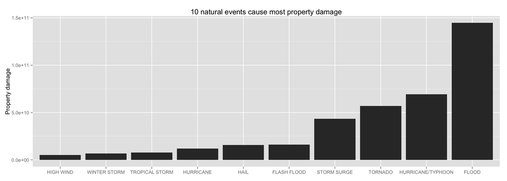

```r
ggplot(most_harmful_to_economic, aes(x = reorder(EVTYPE, PROPDMG), y = PROPDMG)) +
  geom_bar(stat = "identity") +
  ggtitle("10 natural events cause most property damage") +
  ylab("Property damage") +
  theme(axis.title.x = element_blank())
```

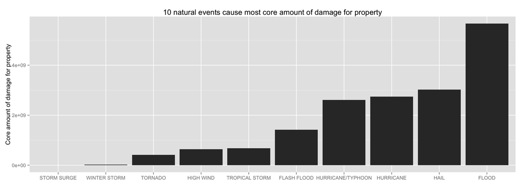

```r
ggplot(most_harmful_to_economic) + aes(x = reorder(EVTYPE, CROPDMG), y = CROPDMG) +
  geom_bar(stat = "identity") +
  ggtitle("10 natural events cause most core amount of damage for property") +
  ylab("Core amount of damage for property") +
  theme(axis.title.x = element_blank())
```